Introduction to Bayesian Learning — Course Project

# Bayesian Analysis of US Spot Bitcoin ETFs

Market structure, return inference, and tracking efficiency — through a Bayesian lens

Dataset 597 trading days · Jan 2024 – Jun 2026

Methods Beta-Binomial · Normal-InvGamma · MCMC

Context

## The same asset. Six wrappers. One day.

IBITBlackRock iSharesFee 0.25% · AUM rank #1

FBTCFidelityFee 0.25% · AUM rank #2

BITBBitwiseFee 0.20% · AUM rank #3

ARKBARK 21SharesFee 0.21% · AUM rank #4

HODLVanEckFee 0.20% · AUM rank #5

BTCOInvesco GalaxyFee 0.25% · AUM rank #6

All six launched on January 11, 2024. All hold only spot Bitcoin. Any differences in market behaviour must come from *fee, brand, or institutional backing* — making this an unusually clean natural experiment for Bayesian inference.

Data

## 597 trading days of prices and volumes

VARIABLES CONSTRUCTED

- Daily log-return: r_t = log(P_t / P_{t-1})
- Daily volume share: s_{k,t} = vol_k / Σvol
- Daily tracking error: TE_{k,t} = r_ETF − r_BTC

SAMPLE SPLIT

- Year 1 Jan 2024 – Jan 2025 · 250 days
- Year 2+ Jan 2025 – Jun 2026 · 347 days

Source: Yahoo Finance via quantmod · Return correlation across all pairs: 0.9995–0.9998

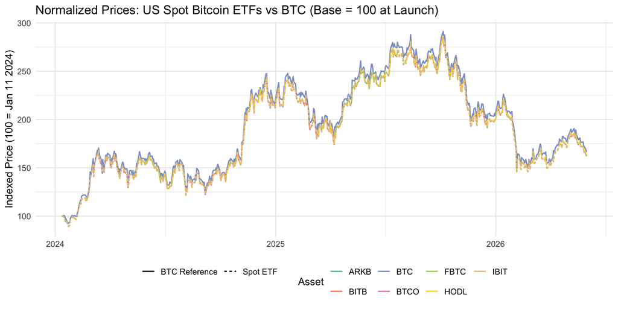

Fig 1 · Normalised prices — all ETFs + BTC (base 100 at launch)

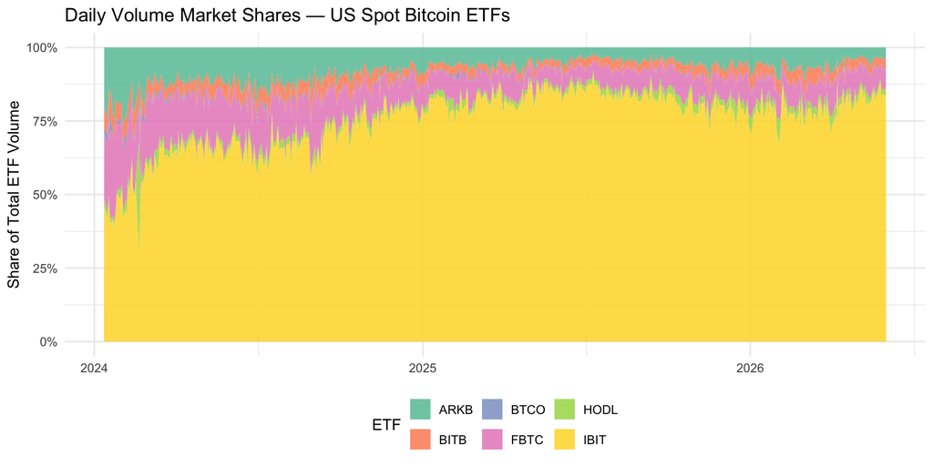

Fig 2 · Daily volume shares — convergence on IBIT by 2025

Methodology

## Five questions, four Bayesian tools

BETA-BINOMIAL CONJUGACY

Proportion inference for market dominance. Prior: Beta(α₁,α₂) → closed-form posterior.

NORMAL-INVGAMMA CONJUGATE

Return and variance inference. Marginal posterior follows scaled t-distribution analytically.

IMPROPER JEFFREYS PRIOR

Shows Bayesian ≡ frequentist t-test numerically. Scaled inv-χ² posterior for σ².

BAYESIAN REGRESSION (MCMC)

brms/Stan HMC sampler. Priors on β informed by ETF mechanics. Convergence via R-hat + ESS.

Prior × Likelihood ∝ Posterior | Beta-Binomial · Normal-InvGamma · Scaled inv-χ² · NUTS (HMC)

Section 2 · Beta-Binomial

## Has BlackRock's dominance eroded?

IBIT captured >50% of total volume on almost every day — making any test at that threshold degenerate. We use a **sharper threshold**:

π = P(IBIT volume share > 70% on day t)

Estimated separately for Year 1 (pre-Jan 2025) and Year 2+ (post-Jan 2025). Prior: Uniform Beta(1,1) encoding no prior view on BlackRock's advantage.

Three priors compared

Uniform Beta(1,1)mean 0.50

Jeffreys Beta(0.5,0.5)mean 0.50

Informative Beta(9.5,3.0)mean 0.76

Posterior update (uniform prior)

π | y ~ Beta(y+1, n−y+1)

With n≥250, prior weight < 1%. Data dominates.

Section 2 · Key Finding

## Dominance didn't erode. It became absolute.

Year 1 · Jan 2024 – Jan 2025 · n=250 34.8% of days IBIT crossed 70% threshold 95% HPD: (0.290, 0.408)

Year 2+ · Jan 2025 – Jun 2026 · n=347 99.7% of days IBIT crossed 70% threshold 95% HPD: (0.989, 1.000)

95% CI for π₂ − π₁: (+0.585, +0.703)  
χ² = 307.3 · p < 2.2 × 10⁻¹⁶

Prior sensitivity check (uniform prior)

Year 1 MLE0.348

Year 1 post. mean0.349

Year 2+ MLE0.997

Year 2+ post. mean0.994

Why the test returns P = 0

Not a degenerate failure — the posteriors are so far apart that 10 million Monte Carlo draws find no sample where Year 1 > Year 2+. The gap *is* the finding. Posterior pdfs visualised → next slide.

Section 2 · Visualizations

## Posterior pdfs and predictive distribution

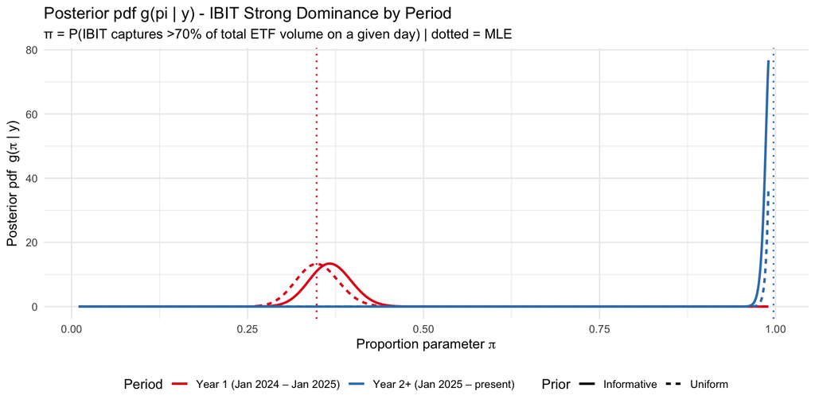

Posterior Beta pdfs — Year 1 vs Year 2+. Non-overlapping distributions.

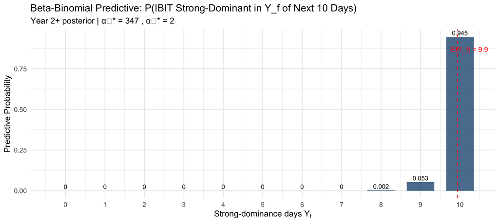

Beta-Binomial predictive — next 10 days · P(all 10 dominant) = 0.945

Prior sensitivity: even with α=100 (symmetric), prior weight is only 37%. With n≥250, the prior is irrelevant.

Section 3 · Non-IBIT Competition

## A three-tier market emerged

Days each ETF led among the 5 non-IBIT competitors (n=597) · Fair share = 20%

FBTC

79.4%

ARKB

20.4%

HODL

0.2%

BITB

0.0%

BTCO

0.0%

Fair

20%

FBTC — undisputed #2 P(π > 0.20) = 1.000

ARKB — right at fair share P(π > 0.20) = 0.628 The only genuinely uncertain result in this section

BITB · HODL · BTCO P(π > 0.20) ≈ 0.000

Bonferroni (10 pairs): FBTC leads all *** · ARKB leads BITB/HODL/BTCO *** · BITB vs HODL vs BTCO: no evidence

Section 4 · Normal-InvGamma Conjugacy

## Can we detect a positive expected return?

Y_i | μ, σ² ~ N(μ, σ²) iid  
μ | σ² ~ N(μ₀, σ²/n₀) [prior on mean]  
σ² ~ InvGamma(α, β) [prior on variance]

- **EMH prior**: μ₀ = 0 — if positive returns were predictable, arbitrage eliminates them
- **n₀ = 2** imaginary prior observations → prior weight < 0.34%
- **InvGamma(0.5, 0.5)** for σ² — 95% interval for σ is (44.7%, 3191%) → essentially flat over realistic values
- Marginal posterior for μ: *closed-form scaled t-distribution*

Posterior mean (shrinkage formula)

E(μ|y) = [n/(n₀+n)] × ȳ + [n₀/(n₀+n)] × μ₀

With n=597 and n₀=2: data gets 99.7% weight

Posterior standard deviation

σ_n = √(2β* / (n + n₀ − 1))

Section 4 · Results

## P(μ > 0) ≈ 0.63 for all ETFs — the EMH is not rejected

| ETF | Post. mean | 95% CI lower | 95% CI upper | P(μ>0) |
| --- | --- | --- | --- | --- |
| IBIT | 0.000747 | −0.00340 | +0.00489 | 0.630 |
| FBTC | 0.000747 | −0.00340 | +0.00489 | 0.630 |
| BITB | 0.000745 | −0.00340 | +0.00483 | 0.630 |
| ARKB | 0.000746 | −0.00339 | +0.00483 | 0.630 |
| HODL | 0.000753 | −0.00338 | +0.00489 | 0.632 |
| BTCO | 0.000754 | −0.00338 | +0.00489 | 0.632 |

597 observations are nowhere near enough to pin down the mean of a process with this much variance. The 95% CI crossing zero by a wide margin is the EMH in action, not a flaw in the analysis.

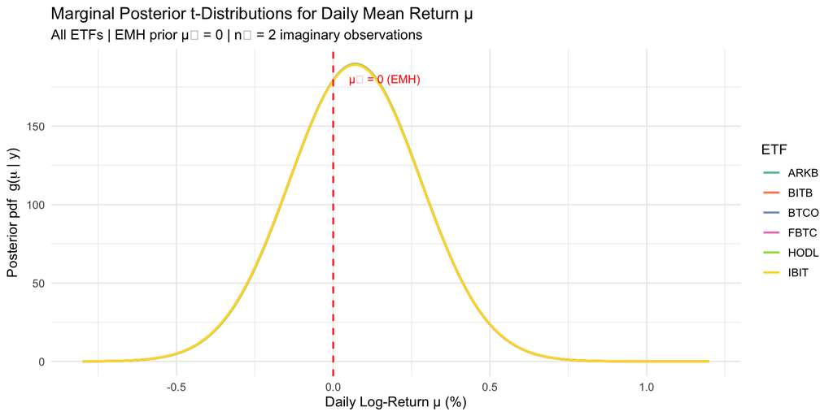

Marginal posterior t-distributions for μ — all six ETFs overlap completely · EMH prior μ₀ = 0 shown as dashed line

Section 5 · Improper Priors

## Bayesian and frequentist give identical results

Under the **improper Jeffreys prior** p(μ, σ²) ∝ 1/σ², the posterior is analytically identical to the frequentist t-distribution. The 95% credible interval equals the 95% confidence interval *to five decimal places*.

| Quantity | Bayesian (improper) | Frequentist |
| --- | --- | --- |
| 95% Interval lower | −0.00183 | −0.00183 |
| 95% Interval upper | +0.00324 | +0.00324 |
| P(μ < 0) / p-value | 0.293 | 0.587 (two-sided) |

Interpretation differs: Bayesian gives P(hypothesis|data); frequentist gives P(data|hypothesis).

Next trading day (1-day prediction) ±6.2% 95% posterior predictive interval: (−6.13%, +6.27%)

Next 30-day mean (1-month prediction) ±1.2% 95% posterior predictive interval: (−1.08%, +1.23%)

Width ∝ √(1/m + 1/n) → s/√n as m → ∞  
Prediction interval narrowing as sample size grows

Section 6 · InvGamma Variance Inference

## Can we rank ETFs by tracking quality?

Daily tracking error: TE = r_ETF − r_BTC. Under improper Jeffreys prior, the posterior for σ²_TE is the scaled inverse chi-squared — same formula as in the conjugate Normal case.

| ETF | Fee | σ_TE (bps/day) | Excess drag |
| --- | --- | --- | --- |
| IBIT | 0.25% | 136.9 | −0.11 bps |
| FBTC | 0.25% | 136.5 | −0.11 bps |
| BITB | 0.20% | 135.8 | −0.15 bps |
| ARKB | 0.21% | 136.4 | −0.13 bps |
| HODL | 0.20% | 135.7 | −0.06 bps |
| BTCO | 0.25% | 135.7 | −0.04 bps |

Bartlett K² = 0.096 · p = 0.9999 · All 15 Bonferroni pairs: "ns"

Why variances are indistinguishable

BTC trades 24/7. ETFs trade 9:30am–4pm. An overnight Bitcoin move of 2% hits all six ETFs *identically* at open. This common shock ≈ 136 bps/day dwarfs fee differences of ≈ 0.05 bps/day — a 2,700× ratio.

What IS informative: mean tracking error

BITB loses 0.15 bps/day above its stated fee — nearly double its expected drag. HODL and BTCO come closest to their stated expense ratio. Hidden execution costs are real but small.

Section 7 · Bayesian Regression · Main Finding

IBIT daily return = α + β × BTC return + ε

Under perfect replication: α = 0 and β = **1.000**

β = 0.932

95% CI: (0.897, 0.967) R² = 0.817

99.99% P(β < 1.00 | data)  
Near-certain systematic under-tracking

84.6% P(β < 0.95 | data)  
Strong evidence of >5% lag

39.4% P(α > 0 | data)  
No evidence of positive alpha (EMH)

R² = 0.817 means 18% of IBIT's daily variance is unrelated to Bitcoin's same-day return. Cause: overnight BTC moves appear in the *next day's* ETF opening price → structural β < 1.

Section 7 · Time-Split Regression

## Is tracking improving as the market matures?

| Period | β (mean) | 95% CI | P(β<1) | P(β<0.95) |
| --- | --- | --- | --- | --- |
| Year 1 | 0.928 | (0.878, 0.979) | 0.997 | 0.796 |
| Year 2+ | 0.940 | (0.894, 0.986) | 0.994 | 0.659 |
| Full | 0.932 | (0.897, 0.967) | 0.9999 | 0.846 |

P(β improves Year 1 → Year 2+) 0.641 Moderate directional evidence of improvement,  
not conclusive — gap from 1.000 remains in both periods

Volume share predictor: P(γ > 0) = 0.758, CI (−0.007, +0.014) → no premium. Prior sensitivity: informative N(1,0.1) vs diffuse N(0,10) → β changes by 0.002. Data dominates — large-sample convergence.

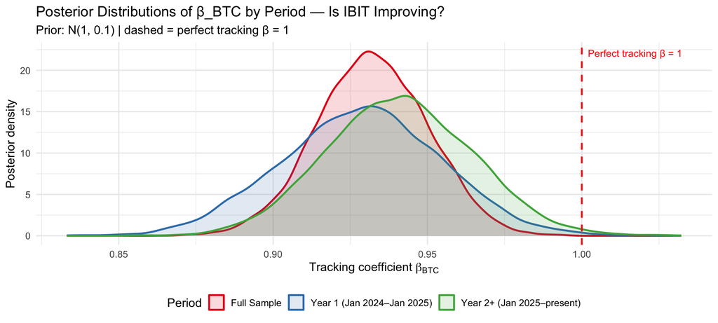

β_BTC posterior distributions — Year 1, Year 2+, Full sample · dashed = perfect tracking β = 1

Section 8 · Prior Sensitivity + MCMC

## Data dominates priors. All chains converged.

PRIOR SENSITIVITY — β_BTC

| Prior on β | Post. mean | 95% CI |
| --- | --- | --- |
| Informative N(1, 0.1) | 0.932 | (0.897, 0.966) |
| Diffuse N(0, 10) | 0.930 | (0.895, 0.965) |

Difference: 0.002. With 597 observations, the likelihood overwhelms any reasonable prior — data dominates entirely.

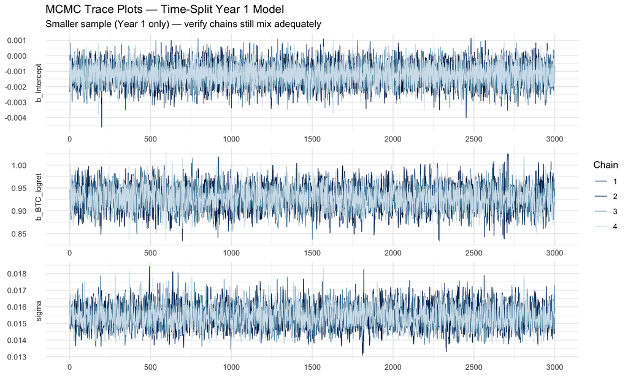

Trace plots — dense caterpillar pattern = good mixing

MCMC DIAGNOSTICS — ALL 4 MODELS

| Model | Max R-hat | Min ESS | Status |
| --- | --- | --- | --- |
| Tracking (simple) | 1.003 | 5,480 | ✓ OK |
| Tracking (extended) | 1.001 | 7,186 | ✓ OK |
| Time-split Y1 | 1.000 | 5,293 | ✓ OK |
| Time-split Y2+ | 1.001 | 5,188 | ✓ OK |

R-hat ≤ 1.01 → all chains same distribution  
Min ESS 5,188 — 13× the 400 threshold

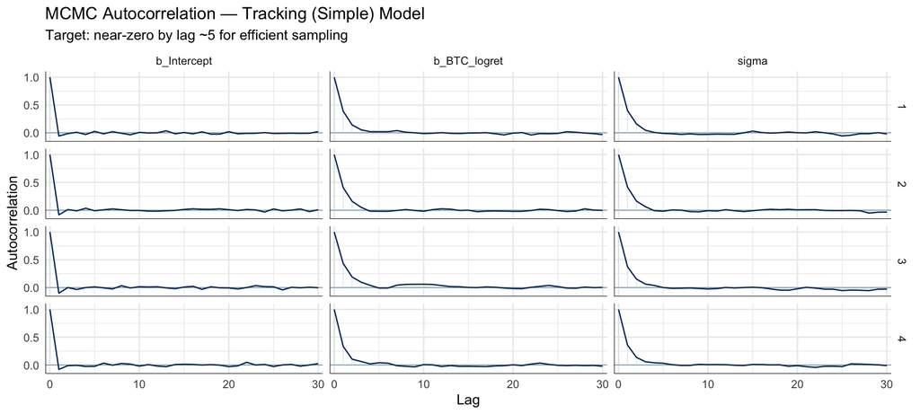

ACF — autocorrelation near zero by lag 5

Conclusions

## Five questions. Four answers. One surprise.

Q1 · Has IBIT's dominance eroded?

**No — it became absolute.** 34.8% in Year 1 → 99.7% in Year 2+. The market converged on BlackRock. Posteriors don't overlap.

Q2 · Who leads the second tier?

**FBTC, decisively.** 79.4% of days. ARKB sits right at fair share (P=0.628). BITB/HODL/BTCO are negligible.

Q3 · Positive expected return?

Q4 · Rank ETFs by tracking quality?

**Not possible from daily prices.** Overnight BTC noise (136 bps/day) is 2,700× larger than fee differences (0.05 bps/day). All σ_TE posteriors overlap completely.

Q5 · Does IBIT faithfully track Bitcoin? ← The surprise

**β = 0.932, P(β < 1) = 0.9999.** A spot ETF holding only BTC should have β = 1.000 and R² > 0.99. It has neither. The 24/7 market vs 6.5h trading window creates a structural lag. No positive alpha. Consistent with EMH.

Discussion

## Three limitations worth acknowledging

01 · DAILY DATA

Intraday bid-ask spreads and creation/redemption delays drive real tracking quality differences. Daily closing prices cannot resolve these — all σ_TE posteriors collapse to one number. Intraday data would give a richer picture.

02 · TWO-YEAR WINDOW

The regime-shift finding covers only the first two years of a genuinely new product class. The market is still settling. The three-tier structure (IBIT, FBTC, everyone else) may not be the long-run equilibrium.

03 · NORMALITY

The Normal-InvGamma model assumes iid Gaussian returns. Bitcoin has heavier tails. A Student-t likelihood would be more robust, but at the cost of the clean conjugate posteriors that made Sections 4–6 analytically tractable.

All code: quantmod · binom · LearnBayes · HDInterval · MCMCpack · brms · bayesplot · BayesFactor · invgamma · extraDistr

Thank you

# Six wrappers. One winner. Much to learn.

0.932

β_BTC · P(<1) = 99.99%

99.7%

IBIT strong-dominant days  
in Year 2+

0.628

P(ARKB > fair share)  
The only uncertain result